# RMarkdown for “Variations in Structural MRI Quality Significantly Impacts Commonly-Used Measures of Brain Anatomy”

Jamie Hanson

4/25/2020

# Starting Steps

First, we load relevant libraries, needed for various operations (using the pacman library).

```r
library(pacman)
pacman::p_load(table1, car, pROC, rcompanion, ggplot2, corrplot, knitr, kableExtra)
```

Next, load data (from the related/included csv file)

```r
combined<-read.csv("combined_data.csv")
```

# Methods

For elements our methods section, we note sample demographics, means. etc. This is related to **Methods Section 2.5**. First, we recode and rename variables to make naming more appropriate for table 1 (the R library).  
Notes re: variables–  
-Basic_Demos.Sex = Participant Sex (coded Male / Female)  
-Diagnosis_ClinicianConsensus.NoDX = Participant Clinical Diagnoses (coded as No / Yes)  
-Basic_Demos.Age = Participant Age (coded in # of years)  
-WISC.WISC_FSIQ = Participant Wechsler Intelligence Scale for Children, Full Scale IQ (continuous measure)  
-Physical.BMI = Participant BMI (continuous measure)  
-CAT12_QC_Weighted_Average = MRI Quality Rating (continuous measure)

```r
combined$Basic_Demos.Sex<-car::recode(combined$Basic_Demos.Sex,'0="Male";1="Female"')

combined$Diagnosis_ClinicianConsensus.NoDX<-car::recode(combined$Diagnosis_ClinicianConsensus.NoDX,'1="No History";2="One or more Disorder"')

combined$Sex<-as.factor(combined$Basic_Demos.Sex)

combined$Age<-as.numeric(combined$Basic_Demos.Age)

combined$Diagnosis<-as.factor(combined$Diagnosis_ClinicianConsensus.NoDX)

combined$IQ<-as.numeric(combined$WISC.WISC_FSIQ)

combined$BMI<-as.numeric(combined$Physical.BMI)

combined$StructuralMRIQuality<-as.numeric(combined$CAT12_QC_Weighted_Average)
```

Construction of **Table 1** (via table1 R package)

```r
table1(~ Sex + Age + Diagnosis + IQ + BMI + StructuralMRIQuality, data=combined)
```

|  | Overall (N=388) |
| --- | --- |
| Sex |  |
| Female | 142 (36.6%) |
| Male | 246 (63.4%) |
| Age |  |
| Mean (SD) | 10.1 (3.37) |
| Median [Min, Max] | 9.46 [5.02, 20.8] |
| Diagnosis |  |
| No History | 60 (15.5%) |
| One or more Disorder | 307 (79.1%) |
| Missing | 21 (5.4%) |
| IQ |  |
| Mean (SD) | 98.4 (16.9) |
| Median [Min, Max] | 98.0 [51.0, 145] |
| Missing | 52 (13.4%) |
| BMI |  |
| Mean (SD) | 19.5 (5.20) |
| Median [Min, Max] | 18.0 [11.7, 45.7] |
| Missing | 8 (2.1%) |
| StructuralMRIQuality |  |
| Mean (SD) | 0.832 (0.0668) |
| Median [Min, Max] | 0.855 [0.577, 0.900] |
| Missing | 1 (0.3%) |

# Results

Analyses related to CAT 12 QC Ratings, and Passing [yes/no]. This is related to **Results, Section 4.1**

```r
summary(model_CAT12_pass<-glm(passing~ CAT12_QC_Weighted_Average , family = "binomial", data=combined))
```

```
## Warning: glm.fit: fitted probabilities numerically 0 or 1 occurred
```

```
##
## Call:
## glm(formula = passing ~ CAT12_QC_Weighted_Average, family = "binomial",
##     data = combined)
##
## Deviance Residuals:
##      Min        1Q    Median        3Q       Max
## -2.54796  -0.04294   0.06950   0.12925   2.31214
##
## Coefficients:
##                           Estimate Std. Error z value Pr(>|z|)
## (Intercept)                 -96.29      12.27  -7.848 4.24e-15 ***
## CAT12_QC_Weighted_Average   114.10      14.49   7.877 3.36e-15 ***
## ---
## Signif. codes:  0 '***' 0.001 '**' 0.01 '*' 0.05 '.' 0.1 ' ' 1
##
## (Dispersion parameter for binomial family taken to be 1)
##
##     Null deviance: 534.01  on 386  degrees of freedom
## Residual deviance: 105.60  on 385  degrees of freedom
##   (1 observation deleted due to missingness)
## AIC: 109.6
##
## Number of Fisher Scoring iterations: 8
```

```r
nagelkerke(model_CAT12_pass)
```

```
## $Models
##
## Model: "glm, passing ~ CAT12_QC_Weighted_Average, binomial, combined"
## Null:  "glm, passing ~ 1, binomial, combined"
##
## $Pseudo.R.squared.for.model.vs.null
##                              Pseudo.R.squared
## McFadden                             0.802817
## Cox and Snell (ML)                   0.670770
## Nagelkerke (Cragg and Uhler)         0.895083
##
## $Likelihood.ratio.test
##  Df.diff LogLik.diff  Chisq    p.value
##       -1     -214.98 429.96 1.6607e-95
##
## $Number.of.observations
##
## Model: 387
## Null:  388
##
## $Messages
## [1] "Note: For models fit with REML, these statistics are based on refitting with ML"
##
## $Warnings
## [1] "WARNING: Fitted and null models have different numbers of observations"
```

We also completed a Bayesian GLM, as a supplemental analysis (given the warning message in the above “frequentist” GLM

```r
suppressMessages(library(arm))
summary(bayesglm(passing ~ CAT12_QC_Weighted_Average, data=combined, family="binomial"))
```

```
##
## Call:
## bayesglm(formula = passing ~ CAT12_QC_Weighted_Average, family = "binomial",
##     data = combined)
##
## Deviance Residuals:
##      Min        1Q    Median        3Q       Max
## -2.51505  -0.04799   0.07575   0.13821   2.27601
##
## Coefficients:
##                           Estimate Std. Error z value Pr(>|z|)
## (Intercept)                 -93.36      11.51  -8.108 5.14e-16 ***
## CAT12_QC_Weighted_Average   110.64      13.59   8.141 3.94e-16 ***
## ---
## Signif. codes:  0 '***' 0.001 '**' 0.01 '*' 0.05 '.' 0.1 ' ' 1
##
## (Dispersion parameter for binomial family taken to be 1)
##
##     Null deviance: 534.01  on 386  degrees of freedom
## Residual deviance: 105.66  on 385  degrees of freedom
##   (1 observation deleted due to missingness)
## AIC: 109.66
##
## Number of Fisher Scoring iterations: 11
```

Generating **Figure 1** (ROC Curve with confidence intervals)

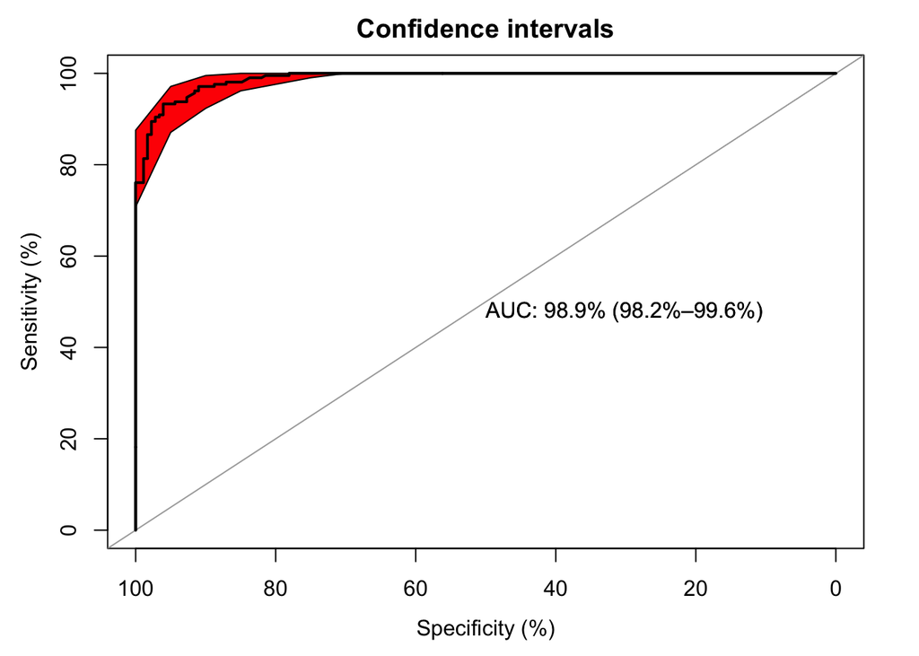

```r
roc<-plot.roc(combined$passing, combined$CAT12_QC_Weighted_Average,main = "Confidence intervals", percent=TRUE,ci = TRUE,print.auc = TRUE, asp = NA,direction="auto")
ciobj <- ci.se(roc,specificities = seq(0, 100, 5))
plot(ciobj, type = "shape", col = "red")
```

Results for relations between sociodemographics and MRI Quality, **Results, Section 4.2**

```r
summary(lm(CAT12_QC_Weighted_Average~ combined$Basic_Demos.Age , data=combined))
```

```
##
## Call:
## lm(formula = CAT12_QC_Weighted_Average ~ combined$Basic_Demos.Age,
##     data = combined)
##
## Residuals:
##      Min       1Q   Median       3Q      Max
## -0.24479 -0.03043  0.01684  0.04584  0.09463
##
## Coefficients:
##                          Estimate Std. Error t value Pr(>|t|)
## (Intercept)              0.767135   0.010193  75.260  < 2e-16 ***
## combined$Basic_Demos.Age 0.006366   0.000956   6.659 9.52e-11 ***
## ---
## Signif. codes:  0 '***' 0.001 '**' 0.01 '*' 0.05 '.' 0.1 ' ' 1
##
## Residual standard error: 0.06333 on 385 degrees of freedom
##   (1 observation deleted due to missingness)
## Multiple R-squared:  0.1033, Adjusted R-squared:  0.101
## F-statistic: 44.34 on 1 and 385 DF,  p-value: 9.522e-11
```

```r
lm.beta::lm.beta(lm(CAT12_QC_Weighted_Average~ combined$Basic_Demos.Age , data=combined))
```

```
##
## Call:
## lm(formula = CAT12_QC_Weighted_Average ~ combined$Basic_Demos.Age,
##     data = combined)
##
## Standardized Coefficients::
##              (Intercept) combined$Basic_Demos.Age
##                0.0000000                0.3213787
```

Generating **Figure 2** (scatterplot of age and MRI Quality)

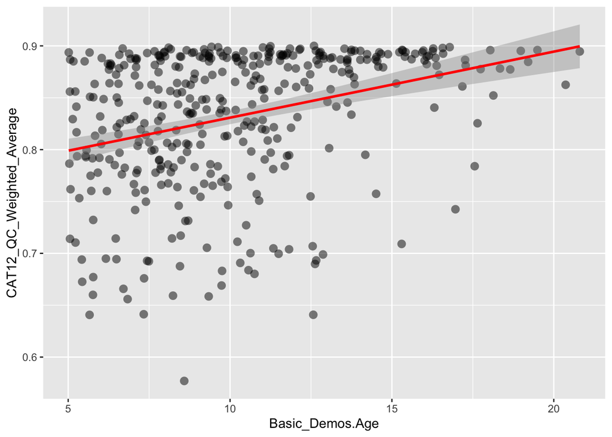

```r
ggplot(combined, aes(y=CAT12_QC_Weighted_Average, x=Basic_Demos.Age)) +geom_point(shape=16, size=3,color = 'black',alpha = 0.5) + geom_smooth(method=lm, color = 'red')
```

Additional Tests in **Results, Section 4.2** (all non-significant)

```r
summary(lm(CAT12_QC_Weighted_Average~ combined$Basic_Demos.Sex , data=combined))
```

```
##
## Call:
## lm(formula = CAT12_QC_Weighted_Average ~ combined$Basic_Demos.Sex,
##     data = combined)
##
## Residuals:
##      Min       1Q   Median       3Q      Max
## -0.26031 -0.03839  0.02059  0.05349  0.07181
##
## Coefficients:
##                               Estimate Std. Error t value Pr(>|t|)
## (Intercept)                   0.837312   0.005600 149.527   <2e-16 ***
## combined$Basic_Demos.SexMale -0.009119   0.007038  -1.296    0.196
## ---
## Signif. codes:  0 '***' 0.001 '**' 0.01 '*' 0.05 '.' 0.1 ' ' 1
##
## Residual standard error: 0.06673 on 385 degrees of freedom
##   (1 observation deleted due to missingness)
## Multiple R-squared:  0.004342,   Adjusted R-squared:  0.001756
## F-statistic: 1.679 on 1 and 385 DF,  p-value: 0.1958
```

```r
summary(lm(CAT12_QC_Weighted_Average~ combined$WISC.WISC_FSIQ , data=combined))
```

```
##
## Call:
## lm(formula = CAT12_QC_Weighted_Average ~ combined$WISC.WISC_FSIQ,
##     data = combined)
##
## Residuals:
##      Min       1Q   Median       3Q      Max
## -0.25673 -0.03981  0.02371  0.05312  0.08403
##
## Coefficients:
##                          Estimate Std. Error t value Pr(>|t|)
## (Intercept)             0.7944234  0.0212365  37.408   <2e-16 ***
## combined$WISC.WISC_FSIQ 0.0003971  0.0002128   1.866    0.063 .
## ---
## Signif. codes:  0 '***' 0.001 '**' 0.01 '*' 0.05 '.' 0.1 ' ' 1
##
## Residual standard error: 0.06571 on 333 degrees of freedom
##   (53 observations deleted due to missingness)
## Multiple R-squared:  0.01034,    Adjusted R-squared:  0.007372
## F-statistic:  3.48 on 1 and 333 DF,  p-value: 0.06298
```

```r
lm.beta::lm.beta(lm(CAT12_QC_Weighted_Average~ combined$WISC.WISC_FSIQ , data=combined))
```

```
##
## Call:
## lm(formula = CAT12_QC_Weighted_Average ~ combined$WISC.WISC_FSIQ,
##     data = combined)
##
## Standardized Coefficients::
##             (Intercept) combined$WISC.WISC_FSIQ
##               0.0000000               0.1017036
```

```r
summary(lm(CAT12_QC_Weighted_Average~ combined$Physical.BMI , data=combined))
```

```
##
## Call:
## lm(formula = CAT12_QC_Weighted_Average ~ combined$Physical.BMI,
##     data = combined)
##
## Residuals:
##      Min       1Q   Median       3Q      Max
## -0.25233 -0.03903  0.02039  0.05508  0.07150
##
## Coefficients:
##                        Estimate Std. Error t value Pr(>|t|)
## (Intercept)           0.8160979  0.0132609  61.542   <2e-16 ***
## combined$Physical.BMI 0.0007959  0.0006584   1.209    0.227
## ---
## Signif. codes:  0 '***' 0.001 '**' 0.01 '*' 0.05 '.' 0.1 ' ' 1
##
## Residual standard error: 0.06662 on 377 degrees of freedom
##   (9 observations deleted due to missingness)
## Multiple R-squared:  0.003861,   Adjusted R-squared:  0.001219
## F-statistic: 1.461 on 1 and 377 DF,  p-value: 0.2275
```

```r
summary(lm(CAT12_QC_Weighted_Average~ combined$Diagnosis_ClinicianConsensus.NoDX , data=combined))
```

```
##
## Call:
## lm(formula = CAT12_QC_Weighted_Average ~ combined$Diagnosis_ClinicianConsensus.NoDX,
##     data = combined)
##
## Residuals:
##      Min       1Q   Median       3Q      Max
## -0.25163 -0.04105  0.02180  0.05647  0.07136
##
## Coefficients:
##                                                                 Estimate
## (Intercept)                                                     0.841258
## combined$Diagnosis_ClinicianConsensus.NoDXOne or more Disorder -0.012624
##                                                                Std. Error
## (Intercept)                                                      0.008779
## combined$Diagnosis_ClinicianConsensus.NoDXOne or more Disorder   0.009601
##                                                                t value Pr(>|t|)
## (Intercept)                                                     95.828   <2e-16
## combined$Diagnosis_ClinicianConsensus.NoDXOne or more Disorder  -1.315    0.189
##
## (Intercept)                                                    ***
## combined$Diagnosis_ClinicianConsensus.NoDXOne or more Disorder
## ---
## Signif. codes:  0 '***' 0.001 '**' 0.01 '*' 0.05 '.' 0.1 ' ' 1
##
## Residual standard error: 0.068 on 364 degrees of freedom
##   (22 observations deleted due to missingness)
## Multiple R-squared:  0.004727,   Adjusted R-squared:  0.001993
## F-statistic: 1.729 on 1 and 364 DF,  p-value: 0.1894
```

Additional Analyses in **Results, Section 4.2** (only the subjects that pass visual inspection)

```r
OnlySubsPassingVisualQC<-subset(combined,combined$passing==1)

summary(lm(CAT12_QC_Weighted_Average~ Basic_Demos.Age , data=OnlySubsPassingVisualQC))
```

```
##
## Call:
## lm(formula = CAT12_QC_Weighted_Average ~ Basic_Demos.Age, data = OnlySubsPassingVisualQC)
##
## Residuals:
##       Min        1Q    Median        3Q       Max
## -0.059566 -0.008473  0.006150  0.011464  0.020412
##
## Coefficients:
##                  Estimate Std. Error t value Pr(>|t|)
## (Intercept)     0.8724908  0.0038720 225.332   <2e-16 ***
## Basic_Demos.Age 0.0006879  0.0003263   2.108   0.0362 *
## ---
## Signif. codes:  0 '***' 0.001 '**' 0.01 '*' 0.05 '.' 0.1 ' ' 1
##
## Residual standard error: 0.01696 on 207 degrees of freedom
## Multiple R-squared:  0.02102,    Adjusted R-squared:  0.01629
## F-statistic: 4.445 on 1 and 207 DF,  p-value: 0.03621
```

```r
summary(lm(CAT12_QC_Weighted_Average~ Basic_Demos.Sex , data=OnlySubsPassingVisualQC))
```

```
##
## Call:
## lm(formula = CAT12_QC_Weighted_Average ~ Basic_Demos.Sex, data = OnlySubsPassingVisualQC)
##
## Residuals:
##       Min        1Q    Median        3Q       Max
## -0.057692 -0.006692  0.006416  0.012008  0.020008
##
## Coefficients:
##                     Estimate Std. Error t value Pr(>|t|)
## (Intercept)         0.878792   0.001855 473.851   <2e-16 ***
## Basic_Demos.SexMale 0.002492   0.002408   1.035    0.302
## ---
## Signif. codes:  0 '***' 0.001 '**' 0.01 '*' 0.05 '.' 0.1 ' ' 1
##
## Residual standard error: 0.0171 on 207 degrees of freedom
## Multiple R-squared:  0.005149,   Adjusted R-squared:  0.0003428
## F-statistic: 1.071 on 1 and 207 DF,  p-value: 0.3019
```

```r
summary(lm(CAT12_QC_Weighted_Average~ WISC.WISC_FSIQ , data=OnlySubsPassingVisualQC))
```

```
##
## Call:
## lm(formula = CAT12_QC_Weighted_Average ~ WISC.WISC_FSIQ, data = OnlySubsPassingVisualQC)
##
## Residuals:
##      Min       1Q   Median       3Q      Max
## -0.05917 -0.00777  0.00639  0.01163  0.02022
##
## Coefficients:
##                 Estimate Std. Error t value Pr(>|t|)
## (Intercept)    8.762e-01  6.659e-03  131.57   <2e-16 ***
## WISC.WISC_FSIQ 4.467e-05  6.665e-05    0.67    0.504
## ---
## Signif. codes:  0 '***' 0.001 '**' 0.01 '*' 0.05 '.' 0.1 ' ' 1
##
## Residual standard error: 0.01695 on 183 degrees of freedom
##   (24 observations deleted due to missingness)
## Multiple R-squared:  0.002449,   Adjusted R-squared:  -0.003002
## F-statistic: 0.4492 on 1 and 183 DF,  p-value: 0.5035
```

```r
summary(lm(CAT12_QC_Weighted_Average~ Physical.BMI , data=OnlySubsPassingVisualQC))
```

```
##
## Call:
## lm(formula = CAT12_QC_Weighted_Average ~ Physical.BMI, data = OnlySubsPassingVisualQC)
##
## Residuals:
##       Min        1Q    Median        3Q       Max
## -0.059056 -0.006997  0.006650  0.012297  0.019837
##
## Coefficients:
##                Estimate Std. Error t value Pr(>|t|)
## (Intercept)   0.8836391  0.0045000 196.366   <2e-16 ***
## Physical.BMI -0.0001687  0.0002169  -0.778    0.438
## ---
## Signif. codes:  0 '***' 0.001 '**' 0.01 '*' 0.05 '.' 0.1 ' ' 1
##
## Residual standard error: 0.01725 on 202 degrees of freedom
##   (5 observations deleted due to missingness)
## Multiple R-squared:  0.002984,   Adjusted R-squared:  -0.001952
## F-statistic: 0.6045 on 1 and 202 DF,  p-value: 0.4378
```

```r
summary(lm(CAT12_QC_Weighted_Average~ factor(Diagnosis_ClinicianConsensus.NoDX) , data=OnlySubsPassingVisualQC))
```

```
##
## Call:
## lm(formula = CAT12_QC_Weighted_Average ~ factor(Diagnosis_ClinicianConsensus.NoDX),
##     data = OnlySubsPassingVisualQC)
##
## Residuals:
##      Min       1Q   Median       3Q      Max
## -0.05975 -0.00645  0.00605  0.01175  0.01915
##
## Coefficients:
##                                                                 Estimate
## (Intercept)                                                    8.809e-01
## factor(Diagnosis_ClinicianConsensus.NoDX)One or more Disorder -9.381e-05
##                                                               Std. Error
## (Intercept)                                                    2.886e-03
## factor(Diagnosis_ClinicianConsensus.NoDX)One or more Disorder  3.173e-03
##                                                               t value Pr(>|t|)
## (Intercept)                                                    305.24   <2e-16
## factor(Diagnosis_ClinicianConsensus.NoDX)One or more Disorder   -0.03    0.976
##
## (Intercept)                                                   ***
## factor(Diagnosis_ClinicianConsensus.NoDX)One or more Disorder
## ---
## Signif. codes:  0 '***' 0.001 '**' 0.01 '*' 0.05 '.' 0.1 ' ' 1
##
## Residual standard error: 0.01683 on 195 degrees of freedom
##   (12 observations deleted due to missingness)
## Multiple R-squared:  4.483e-06,  Adjusted R-squared:  -0.005124
## F-statistic: 0.0008742 on 1 and 195 DF,  p-value: 0.9764
```

Results for relations between Freesurfer Outputs and MRI Quality, **Results, Section 4.3**. We complete some looped regressions, save relevant statistics, multiple-comparison correction, and then prep for Figure construction.

```r
library(ggseg); library(ggseg3d); library(tidyverse); library(stringr); library(ggsci)
combined_ONLY_passing<-subset(combined,combined$passing==1 & combined$brain.stem!="NA")
Only_Freesurfer_Data<-combined_ONLY_passing[,7:90]
Only_CAT12_QC_Weighted_Average<-data.frame(combined_ONLY_passing$CAT12_QC_Weighted_Average)

n<-84
Loop_to_Extract_Tstats <- lapply(1:n, function(x) lm(Only_Freesurfer_Data[,x] ~ Only_CAT12_QC_Weighted_Average[,1]))
summaries <- lapply(Loop_to_Extract_Tstats, summary)
saved_t_statistics<-lapply(summaries, function(x) x$coefficients[, c(3)])
saved_pvalue<-lapply(summaries, function(x) x$coefficients[, c(4)])

T_Statistics_temp<-lapply(saved_t_statistics, function (x) x[c('Only_CAT12_QC_Weighted_Average[, 1]')])
T_Statistics<-do.call(rbind.data.frame, T_Statistics_temp)

P_Value_temp<-lapply(saved_pvalue, function (x) x[c('Only_CAT12_QC_Weighted_Average[, 1]')])
Pvalue<-do.call(rbind.data.frame, P_Value_temp)
names(Pvalue)[names(Pvalue)=="c.0.0362567175922178..0.0156777311878222..0.104426644108848.."] <- "p_value"

P_value_adjusted<-data.frame(round(p.adjust(Pvalue$p_value, method = "BH", n = length(Pvalue$p_value)),4))

Brain_Areas<-colnames(Only_Freesurfer_Data)
DataFrameForFigure<-data.frame(Brain_Areas,T_Statistics,P_value_adjusted)
names(DataFrameForFigure)[names(DataFrameForFigure)=="c.2.10801383427631..2.4368470062469..1.63106691579897..2.31388238512456.."] <- "t_stats"
names(DataFrameForFigure)[names(DataFrameForFigure)=="round.p.adjust.Pvalue.p_value..method....BH...n...length.Pvalue.p_value...."] <- "p_value_adjusted"

Significant<-subset(DataFrameForFigure,DataFrameForFigure$p_value_adjusted<.05)
```

Making **Figure 3** (Cortical Freesurfer Outputs, Related to MRI Quality)

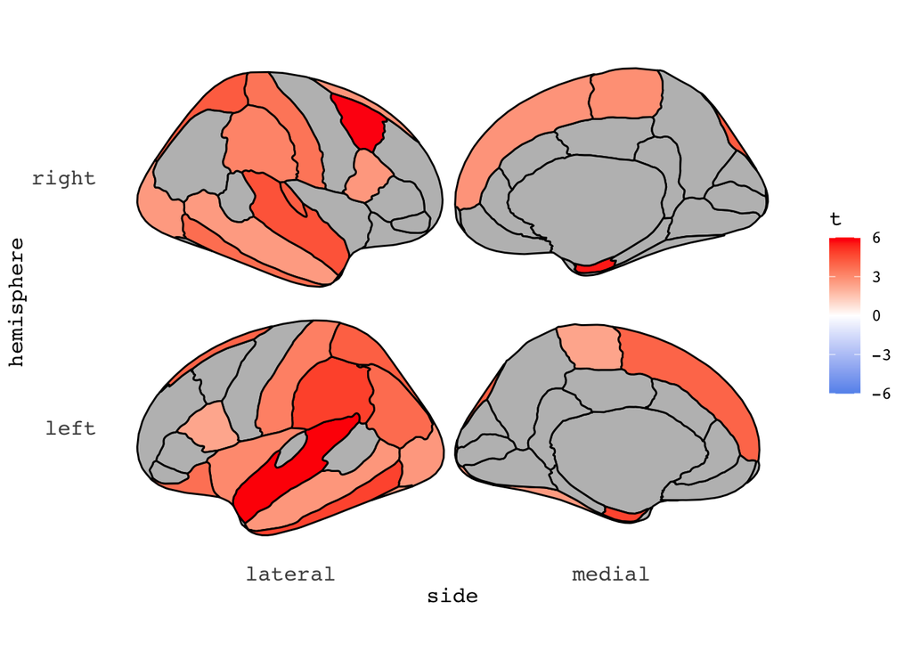

```r
Only_Cortex<-Significant[7:37,]
Only_Cortex_Filenames<-as.character(Only_Cortex$Brain_Areas)
Only_Cortex_t_stats<-Only_Cortex$t_stats

cortical_statistical_values= tibble(label=c(Only_Cortex_Filenames),t=c(Only_Cortex_t_stats))

cortical_statistical_values %>% ggseg(mapping=aes(fill=t),colour="black",position = "stacked")+ scale_fill_gradientn(limits = c(-6,6),colours = c("cornflowerblue","white","red1"),na.value="grey")
```

Making **Figure 4** (Subcortical Freesurfer Outputs, Related to MRI Quality)

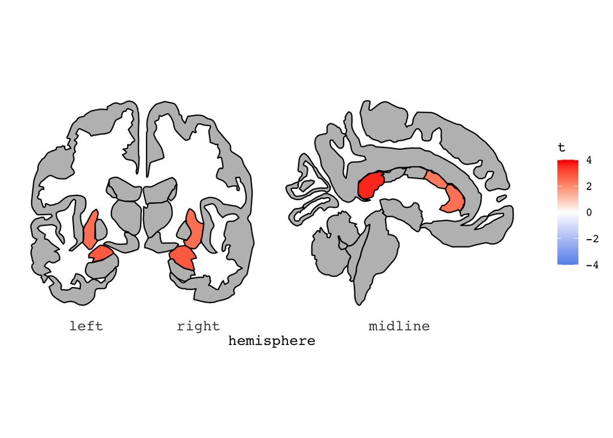

```r
Only_Subcortex<-Significant[1:6,]
Only_Subcortex_Filenames<-as.character(Only_Subcortex$Brain_Areas)
Only_Subcortex_Filenames <- str_replace_all(Only_Subcortex_Filenames, "[.]", "-")
Only_Subcortex_t_stats<-Only_Subcortex$t_stats

aseg_statistical_values= tibble(label=c(Only_Subcortex_Filenames),t=c(Only_Subcortex_t_stats))

aseg_statistical_values %>%
ggseg(mapping=aes(fill=t),colour="black",atlas=aseg)+ scale_fill_gradientn(limits = c(-4,4),colours = c("cornflowerblue","white","red1"),na.value="grey")
```

Output **Table 2** Listing all regions related to MRI Quality

```r
library(knitr); library(kableExtra); library(magick); library(webshot)
```

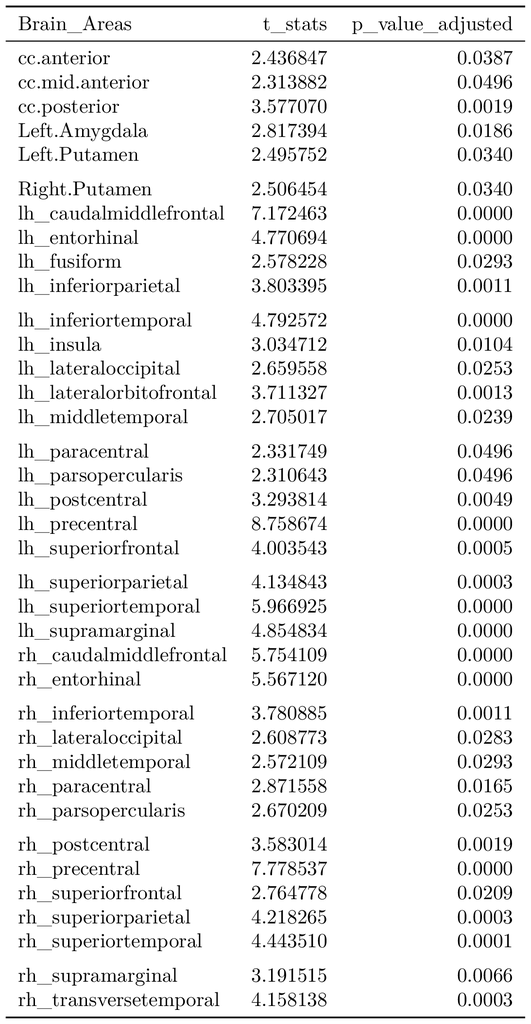

```r
row.names(Significant) <- NULL
kable(Significant, "latex", booktabs = T) %>%
as_image()
```

Output **Figure 5** (two panels)

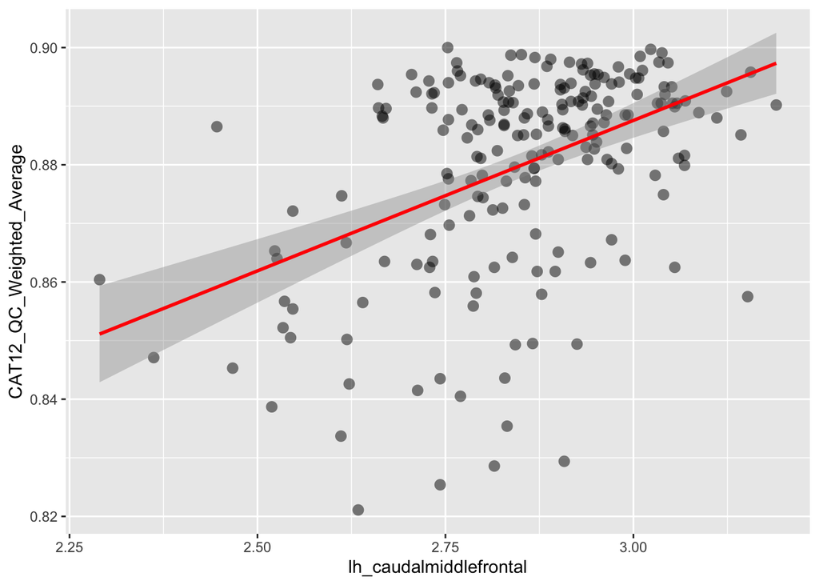

```r
#5A
ggplot(combined_ONLY_passing, aes(y=CAT12_QC_Weighted_Average, x=lh_caudalmiddlefrontal)) +geom_point(shape=16, size=3,color = 'black',alpha = 0.5) + geom_smooth(method=lm, color = 'red')
```

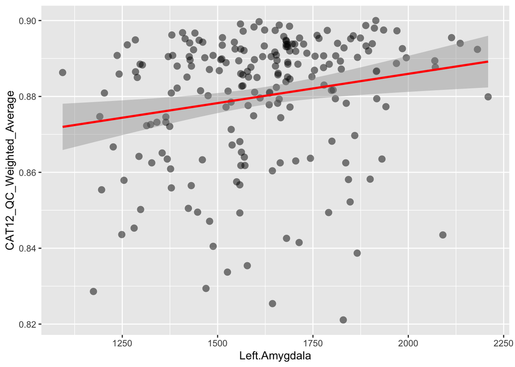

```r
#5B
ggplot(combined_ONLY_passing, aes(y=CAT12_QC_Weighted_Average, x=Left.Amygdala)) +geom_point(shape=16, size=3,color = 'black',alpha = 0.5) + geom_smooth(method=lm, color = 'red')
```